# Self-Driving Car Engineer Nanodegree

## Project: Build a Traffic Sign Recognition Classifier

In this notebook, a template is provided for you to implement your functionality in stages, which is required to successfully complete this project. If additional code is required that cannot be included in the notebook, be sure that the Python code is successfully imported and included in your submission if necessary.

In addition to implementing code, there is a writeup to complete. The writeup should be completed in a separate file, which can be either a markdown file or a pdf document. There is a [write up template](https://github.com/udacity/CarND-Traffic-Sign-Classifier-Project/blob/master/writeup_template.md) that can be used to guide the writing process. Completing the code template and writeup template will cover all of the [rubric points](https://review.udacity.com/#!/rubrics/481/view) for this project.

The [rubric](https://review.udacity.com/#!/rubrics/481/view) contains "Stand Out Suggestions" for enhancing the project beyond the minimum requirements. The stand out suggestions are optional. If you decide to pursue the "stand out suggestions", you can include the code in this Ipython notebook and also discuss the results in the writeup file.

> **Note:** Code and Markdown cells can be executed using the **Shift + Enter** keyboard shortcut. In addition, Markdown cells can be edited by typically double-clicking the cell to enter edit mode.

## Step 0: Load The Data

```python
# Load pickled data
import pickle

training_file = 'F:/sdc/Data/traffic-signs-data/train.p'
validation_file='F:/sdc/Data/traffic-signs-data/valid.p'
testing_file =  'F:/sdc/Data/traffic-signs-data/test.p'

with open(training_file, mode='rb') as f:
    train = pickle.load(f)
with open(validation_file, mode='rb') as f:
    valid = pickle.load(f)
with open(testing_file, mode='rb') as f:
    test = pickle.load(f)

X_train, y_train = train['features'], train['labels']
X_valid, y_valid = valid['features'], valid['labels']
X_test, y_test = test['features'], test['labels']
```

## Step 1: Dataset Summary & Exploration

The pickled data is a dictionary with 4 key/value pairs:

- `'features'` is a 4D array containing raw pixel data of the traffic sign images, (num examples, width, height, channels).
- `'labels'` is a 1D array containing the label/class id of the traffic sign. The file `signnames.csv` contains id -> name mappings for each id.
- `'sizes'` is a list containing tuples, (width, height) representing the original width and height the image.
- `'coords'` is a list containing tuples, (x1, y1, x2, y2) representing coordinates of a bounding box around the sign in the image. **THESE COORDINATES ASSUME THE ORIGINAL IMAGE. THE PICKLED DATA CONTAINS RESIZED VERSIONS (32 by 32) OF THESE IMAGES**

Complete the basic data summary below. Use python, numpy and/or pandas methods to calculate the data summary rather than hard coding the results. For example, the [pandas shape method](http://pandas.pydata.org/pandas-docs/stable/generated/pandas.DataFrame.shape.html) might be useful for calculating some of the summary results.

### Provide a Basic Summary of the Data Set Using Python, Numpy and/or Pandas

```python
### Replace each question mark with the appropriate value.
### Use python, pandas or numpy methods rather than hard coding the results

import numpy as np

assert y_train.shape[0] == X_train.shape[0]
assert y_valid.shape[0] == X_valid.shape[0]
assert y_test.shape[0] == X_test.shape[0]

assert X_train.shape[1:] == X_valid.shape[1:]
assert X_train.shape[1:] == X_test.shape[1:]

# Number of classes/labels. This assumes the labels are integers starting at zero, with no gaps.
n_classes = np.amax(y_train) + 1

print("Number of training examples =", y_train.shape[0])
print("Number of validation examples =", y_valid.shape[0])
print("Number of testing examples =", y_test.shape[0])
print("Image data shape =", X_train.shape[1:])
print("Number of classes =", n_classes)
```

```
Number of training examples = 34799
Number of validation examples = 4410
Number of testing examples = 12630
Image data shape = (32, 32, 3)
Number of classes = 43
```

### Include an exploratory visualization of the dataset

Visualize the German Traffic Signs Dataset using the pickled file(s). This is open ended, suggestions include: plotting traffic sign images, plotting the count of each sign, etc.

The [Matplotlib](http://matplotlib.org/) [examples](http://matplotlib.org/examples/index.html) and [gallery](http://matplotlib.org/gallery.html) pages are a great resource for doing visualizations in Python.

**NOTE:** It's recommended you start with something simple first. If you wish to do more, come back to it after you've completed the rest of the sections. It can be interesting to look at the distribution of classes in the training, validation and test set. Is the distribution the same? Are there more examples of some classes than others?

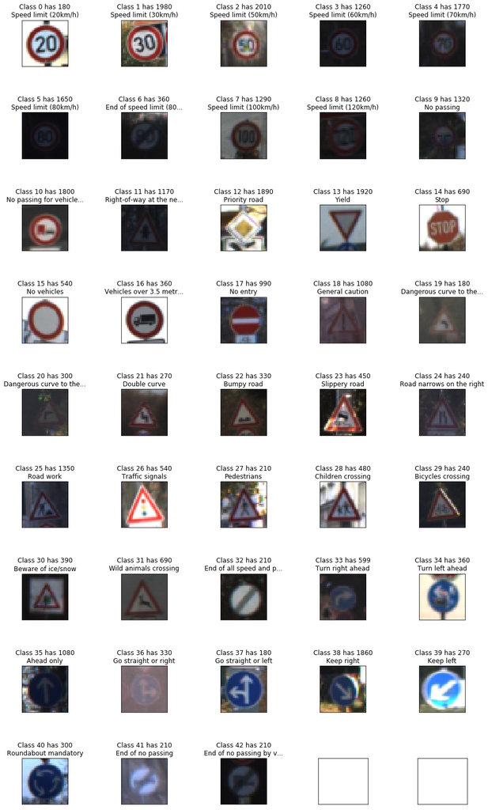

```python
### Data exploration visualization code goes here.
### Feel free to use as many code cells as needed.
import matplotlib.pyplot as plt
# Visualizations will be shown in the notebook.
%matplotlib inline

import random

# This loads the sign names and stores them in a tuple.
def _loadSignNames():
    # Load signnames.csv.
    rawNames = np.genfromtxt(
        fname='signnames.csv', delimiter=',',
        usecols=(0, 1), dtype=[('index', np.int32), ('name', np.object)],
        skip_header=1, skip_footer=0)

    # Convert to a dictionary mapping index tostr/unicode (assuming python 3.x).
    names = {rec[0]: rec[1].decode('utf-8') for rec in rawNames}

    # Convert to a tuple, since the keys are contiguous integers starting at zero.
    assert all(i in names for i in range(len(names)))
    names = tuple(names[i] for i in range(len(names)))

    return names

signNames = _loadSignNames()

def _showRandomCompleteSet():
    """ Display a random representative of each class. """
    numPerRow = 5
    numRows = (n_classes + numPerRow - 1) // numPerRow
    fig, axes = plt.subplots(
        numRows, numPerRow, figsize=(15, 3 * numRows),
        subplot_kw={'xticks': [], 'yticks': []})
    fig.subplots_adjust(hspace=1.0, wspace=1.0)

    rowIndices = np.arange(len(X_train))
    for c, ax in enumerate(axes.flat):
        if c >= n_classes:
            break
        indices = rowIndices[y_train == c]
        index = np.random.choice(indices)
        image = X_train[index].squeeze()
        label = y_train[index]
        assert label == c
        ax.imshow(image)
        txt = signNames[label]
        lenMax = 25
        if len(txt) > lenMax:
            txt = txt[:lenMax - 3] + '...'
        ax.set_title("Class {} has {}\n{}".format(label, len(indices), txt))

    plt.show()

_showRandomCompleteSet()
```

```
Histogram of training labels
[  180.  1980.  2010.  1260.  1770.  1650.   360.  1290.  1260.  1320.
  1800.  1170.  1890.  1920.   690.   540.   360.   990.  1080.   180.
   300.   270.   330.   450.   240.  1350.   540.   210.   480.   240.
   390.   690.   210.   599.   360.  1080.   330.   180.  1860.   270.
   300.   210.   210.]
```

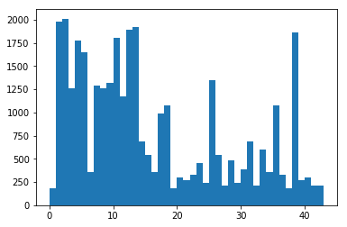

```python
# Show a histogram of the labels in each of the datasets (train, validation, test).
# Ideally, these distributions should be similar, as we see that they are.

def _showHisto(ys, classes, name):
    print("Histogram of {} labels".format(name))
    n, bins, patches = plt.hist(ys, bins=tuple(range(n_classes + 1)))
    #print(n.shape)
    print(n)

_showHisto(y_train, n_classes, "training")
```

```
Histogram of validation labels
[  30.  240.  240.  150.  210.  210.   60.  150.  150.  150.  210.  150.
  210.  240.   90.   90.   60.  120.  120.   30.   60.   60.   60.   60.
   30.  150.   60.   30.   60.   30.   60.   90.   30.   90.   60.  120.
   60.   30.  210.   30.   60.   30.   30.]
```

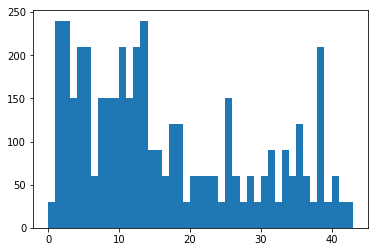

```python
_showHisto(y_valid, n_classes, "validation")
```

```
Histogram of testing labels
[  60.  720.  750.  450.  660.  630.  150.  450.  450.  480.  660.  420.
  690.  720.  270.  210.  150.  360.  390.   60.   90.   90.  120.  150.
   90.  480.  180.   60.  150.   90.  150.  270.   60.  210.  120.  390.
  120.   60.  690.   90.   90.   60.   90.]
```

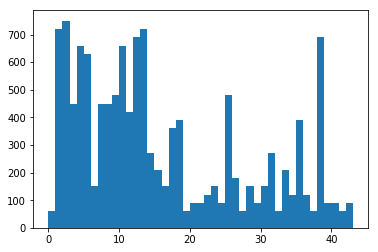

```python
_showHisto(y_test, n_classes, "testing")
```

## Step 2: Design and Test a Model Architecture

Design and implement a deep learning model that learns to recognize traffic signs. Train and test your model on the [German Traffic Sign Dataset](http://benchmark.ini.rub.de/?section=gtsrb&subsection=dataset).

The LeNet-5 implementation shown in the classroom at the end of the CNN lesson is a solid starting point. You'll have to change the number of classes and possibly the preprocessing, but aside from that it's plug and play!

With the LeNet-5 solution from the lecture, you should expect a validation set accuracy of about 0.89. To meet specifications, the validation set accuracy will need to be at least 0.93. It is possible to get an even higher accuracy, but 0.93 is the minimum for a successful project submission.

There are various aspects to consider when thinking about this problem:

- Neural network architecture (is the network over or underfitting?)
- Play around preprocessing techniques (normalization, rgb to grayscale, etc)
- Number of examples per label (some have more than others).
- Generate fake data.

Here is an example of a [published baseline model on this problem](http://yann.lecun.com/exdb/publis/pdf/sermanet-ijcnn-11.pdf). It's not required to be familiar with the approach used in the paper but, it's good practice to try to read papers like these.

### Pre-process the Data Set (normalization, grayscale, etc.)

Minimally, the image data should be normalized so that the data has mean zero and equal variance. For image data, `(pixel - 128)/ 128` is a quick way to approximately normalize the data and can be used in this project.

Other pre-processing steps are optional. You can try different techniques to see if it improves performance.

Use the code cell (or multiple code cells, if necessary) to implement the first step of your project.

```python
### Preprocess the data here. It is required to normalize the data. Other preprocessing steps could include
### converting to grayscale, etc.
### Feel free to use as many code cells as needed.

# This replicates the samples for under-represented classes.
def _balanceTrainSet(x, y, k):
    # Let N be the initial number of samples and k be the number of classes.
    # For a class c, let n(c) be the number of samples for that class.
    # For any class c with n(c) < N / 2, we replicate its samples
    # until n(c) >= N / 2. Note that we don't update N during this process,
    # but then we interate until "convergence".
    while True:
        N = x.shape[0]
        print(N, k, N // (2 * k))
        assert N == y.shape[0]
        samples = [x]
        labels = [y]
        size = N
        for c in range(k):
            xCur = x[y == c]
            n = xCur.shape[0]
            if 0 < n < N // (2 * k):
                p = (N - 1) // (2 * k * n)
                assert p >= 1
                print("Extending class {} by {} copies".format(c, p))
                samples.extend((xCur,) * p)
                labels.append((c,) * (p * n))
                size += n * p

        if len(samples) == 1:
            return x, y

        print(N, size, len(samples))
        print(tuple(s.shape for s in samples))
        xNew = np.concatenate(samples, axis=0)
        yNew = np.concatenate(labels, axis=0)
        print(x.shape, y.shape, xNew.shape, yNew.shape)
        assert xNew.shape[0] == size
        assert yNew.shape[0] == size
        x, y = xNew, yNew

# REVIEW shonk: Simple replication doesn't seem to help. It probably just causes
# over-fitting on those samples. Instead we need to augment with variation. Ideally,
# we should get more samples. I'll leave that for another day...

# X_train, y_train = _balanceTrainSet(X_train, y_train, n_classes)
# _showHisto(y_train, n_classes, "Augmented (balanced) training")
```

```python
# Now normalize the data.
import cv2

# This just subtracts 128 and divides by 128, to map to the interval [-1, +1).
# Note that this makes 'pad' pixels (all zeros) medium gray.
def _normImagesSimple(images):
    assert images.dtype == np.uint8
    res = np.empty_like(images, dtype=np.float32)
    np.subtract(images, 128.0, out=res)
    np.divide(res, 128.0, out=res)
    return res

# This maps to YUV and then subtracts 128 and divides by 128.
def _normImagesYUV(images):
    assert images.dtype == np.uint8
    assert len(images.shape) == 4
    res = np.empty_like(images, dtype=np.float32)
    for i in range(images.shape[0]):
        res[i] = cv2.cvtColor(images[i], cv2.COLOR_RGB2YUV)
    np.subtract(res, 128.0, out=res)
    np.divide(res, 128.0, out=res)
    return res

# This maps to Lab and then subtracts 128 and divides by 128.
def _normImagesLab(images):
    assert images.dtype == np.uint8
    assert len(images.shape) == 4
    res = np.empty_like(images, dtype=np.float32)
    for i in range(images.shape[0]):
        res[i] = cv2.cvtColor(images[i], cv2.COLOR_RGB2Lab)
    np.subtract(res, 128.0, out=res)
    np.divide(res, 128.0, out=res)
    return res

# This maps to gray-scale and then subtracts 128 and divides by 128.
def _normImagesMono(images):
    assert images.dtype == np.uint8
    assert len(images.shape) == 4
    res = np.empty(shape=images.shape[:3] + (1,), dtype=np.float32)
    for i in range(images.shape[0]):
        res[i] = np.expand_dims(cv2.cvtColor(images[i], cv2.COLOR_RGB2GRAY), axis=-1)
    np.subtract(res, 128.0, out=res)
    np.divide(res, 128.0, out=res)
    return res

# I tried several different color spaces. Of these, Mono (gray-scale) fared the worst and
# the others were close to (but not better than) RGB. Might as well keep it simple.
def _normImages(images):
    return _normImagesSimple(images)
    #return _normImagesYUV(images)
    #return _normImagesLab(images)
    #return _normImagesMono(images)

featuresTrain = _normImages(X_train)
featuresValid = _normImages(X_valid)
featuresTest = _normImages(X_test)
```

### Model Architecture

```python
# Import tensorflow and the flatten method.

import tensorflow as tf

from tensorflow.contrib.layers import flatten
```

```python
def BuildDnn(x, kr1, kr2, kr3, rand, dump=False, verbose=False):
    """ Builds a dnn for sign recognition.

    The 'x' parameter should be a placeholder for the input features.
    The 'kr1', 'kr2', and 'kr3' parameters should be placeholders for the dropout keep-rates.
    kr1 is for the fully connected layers, kr2 is for the last convolutional layer, and kr3
    is for the first convolution, that is, it is the keep rate applied to input features
    (normalized pixels).

    It returns the logits and tuple of 'layer' tensors, to be used by visualization below.
    Of course, in a real world application, it would also return the collection of weight
    tensors to facilitate extracting/saving the weights.
    """

    # This deviates from LeNet in a few ways: it uses 3x3 convolutions, not 5x5;
    # it has a couple additional convolutional layers; it uses padding.
    # Recent trends in image recognition are to use 3x3 convolutions, but more of them.

    # Note that the factoring into nested helper functions makes it easy to experiment
    # with different topologies.

    # Mean and standard deviation for weight initialization.
    mu = 0
    sigma = 0.1

    def _Conv(inp, count, size=3):
        """ Apply a convolution, with the given filter count and size. Uses padding. """
        seed = rand.randint(0x80000000)
        if dump and verbose:
            print("Seed: {}".format(seed))
        wts = tf.Variable(
            tf.truncated_normal(
                shape=(size, size, inp.shape[-1].value, count),
                mean=mu, stddev=sigma, seed=seed))
        bias = tf.Variable(tf.zeros(shape=(count,)))
        return tf.nn.bias_add(tf.nn.convolution(input=inp, filter=wts, padding='SAME'), bias)

    def _Full(inp, count):
        """ Apply a fully connected layer, with the given count of cells. """
        seed = rand.randint(0x80000000)
        if dump and verbose:
            print("Seed: {}".format(seed))
        wts = tf.Variable(
            tf.truncated_normal(
                shape=(inp.shape[-1].value, count),
                mean=mu, stddev=sigma, seed=seed))
        bias = tf.Variable(tf.zeros(shape=(count,)))
        return tf.nn.bias_add(tf.matmul(inp, wts), bias)

    def _DropOut(inp, k):
        """ Apply dropout with the given keep rate. """
        seed = rand.randint(0x80000000)
        if dump and verbose:
            print("Seed: {}".format(seed))

        # REVIEW shonk: I'd like to set noise_shape so we either keep or drop an entire 'channel'
        # (all 'pixels' lose the same channels). Unfortunately, noise_shape doesn't appear to play
        # well with an unknown batch size! This is a pretty significant flaw in tensorflow. The
        # simplest work around seems to be to specify the batch size in the graph, but I don't want
        # to do that - it would make dealing with the final 'partial' batch a pain.

        shape = inp.shape
        assert len(shape) >= 2

        if len(shape) > 2 and False:
            # This fails, as described above, when shape[0] is None, hence the 'and False'.
            shape = tf.TensorShape((shape[0],) + (1,) * (len(shape) - 2) + (shape[-1],))
        else:
            shape = None

        return tf.nn.dropout(inp, k, noise_shape=shape, seed=seed)

    def _Act(inp):
        """ Apply the activation function. We just use relu. """
        return tf.nn.relu(inp)

    def _Pool(inp, size, stride=None):
        """ Apply max pooling with the given size and stride. When stride is None, it is assumed
        to be the same as size.
        """
        if stride is None:
            stride = size
        return tf.nn.max_pool(inp, ksize=(1, size, size, 1), strides=(1, stride, stride, 1), padding='SAME')

    def _Dump(name, inp):
        """ Dump useful information, if 'dump' is True. """
        if dump:
            print("Layer '{}' has shape: {}".format(name, inp.shape))

    # This uses a number of 3x3 convolutions, with 2x2 max pooling after most, then finishes
    # with a couple fully-connected layers.

    layers = []

    cur = x
    layers.append(cur)
    _Dump("Input", cur)

    # Convolution and pool.
    cur = _DropOut(cur, kr3)
    cur = _Conv(cur, 16)
    cur = _Act(cur)
    layers.append(cur)
    cur = _Pool(cur, 2)
    layers.append(cur)
    _Dump("First Conv + Pool", cur)

    # Convolution, without pooling. Without this, the capacity is
    # a bit too low to get above 97%.
    cur = _Conv(cur, 16)
    cur = _Act(cur)
    layers.append(cur)
    _Dump("Second Conv", cur)

    # Convolution and pool.
    cur = _Conv(cur, 32)
    cur = _Act(cur)
    layers.append(cur)
    cur = _Pool(cur, 2)
    layers.append(cur)
    _Dump("Third Conv + Pool", cur)

    # Convolution and pool.
    cur = _DropOut(cur, kr2)
    cur = _Conv(cur, 64)
    cur = _Act(cur)
    layers.append(cur)
    cur = _Pool(cur, 2)
    layers.append(cur)
    _Dump("Fourth Conv + Pool", cur)

    # Flatten for the fully connected layers.
    cur = flatten(cur)
    _Dump("Flattened", cur)

    # Fully connected. I also tried a smaller number of nodes, but the
    # capacity was then insufficient.
    cur = _DropOut(cur, kr1)
    cur = _Full(cur, 512)
    cur = _Act(cur)
    layers.append(cur)
    _Dump("First Fully Connected", cur)

    # Final fully connected, with no activation, since softmax will be
    # integrated with cross-entropy.
    cur = _DropOut(cur, kr1)
    cur = _Full(cur, 43)
    layers.append(cur)
    _Dump("Logits", cur)

    return cur, layers
```

### Train, Validate and Test the Model

A validation set can be used to assess how well the model is performing. A low accuracy on the training and validation sets imply underfitting. A high accuracy on the training set but low accuracy on the validation set implies overfitting.

```python
### Train your model here.
### Calculate and report the accuracy on the training and validation set.
### Once a final model architecture is selected,
### the accuracy on the test set should be calculated and reported as well.
### Feel free to use as many code cells as needed.

# Initialize the random number generator. This is so the results are reproducible.
rand = np.random.RandomState(42)

# Build the graph. We use the convention that graph nodes, both tensors and non-tensors,
# start with g_.

# Learning rate and dropout keep rate placeholders.
g_lr = tf.placeholder(tf.float32, ())
g_kr1 = tf.placeholder(tf.float32, ())
g_kr2 = tf.placeholder(tf.float32, ())
g_kr3 = tf.placeholder(tf.float32, ())

# Input placeholders (features and labels)
g_x = tf.placeholder(tf.float32, (None,) + featuresTrain.shape[1:])
g_y = tf.placeholder(tf.int32, (None,))

# One-hot label indicators.
g_yInd = tf.one_hot(g_y, 43)

# Build the DNN graph.
g_logits, _layersAll = BuildDnn(g_x, g_kr1, g_kr2, g_kr3, rand, dump=True)

# For reporting statistics.
g_correct = tf.equal(tf.argmax(g_logits, axis=1, output_type=tf.int32), g_y)
g_correct_sum = tf.reduce_sum(tf.cast(g_correct, tf.int32))

# Apply softmax and cross entropy.
g_ce = tf.nn.softmax_cross_entropy_with_logits(labels=g_yInd, logits=g_logits)

# We'll use the loss-sum when reporting statistics, and the loss-mean when training.
g_loss_sum = tf.reduce_sum(g_ce)
g_loss_mean = tf.reduce_mean(g_ce)

# Use Adam with the place-holder learning rate.
g_optimizer = tf.train.AdamOptimizer(learning_rate=g_lr)
g_train_step = g_optimizer.minimize(g_loss_mean)
```

```
Layer 'Input' has shape: (?, 32, 32, 3)
Layer 'First Conv + Pool' has shape: (?, 16, 16, 16)
Layer 'Second Conv' has shape: (?, 16, 16, 16)
Layer 'Third Conv + Pool' has shape: (?, 8, 8, 32)
Layer 'Fourth Conv + Pool' has shape: (?, 4, 4, 64)
Layer 'Flattened' has shape: (?, 1024)
Layer 'First Fully Connected' has shape: (?, 512)
Layer 'Logits' has shape: (?, 43)
```

```python
import time

def _eval(sess, xsAll, ysAll, batchSize=100):
    """ Returns the number of correct predictions, sum of losses, and the number of samples.
    The caller can divide the first two by the third to get averages.
    """
    assert batchSize > 0
    assert xsAll.shape[0] == ysAll.shape[0]
    num = xsAll.shape[0]

    acc_sum = 0
    loss_sum = 0.0
    for ii in range(0, num, batchSize):
        xs = xsAll[ii : ii + batchSize]
        ys = ysAll[ii : ii + batchSize]
        acc, loss = sess.run(
            (g_correct_sum, g_loss_sum),
            feed_dict={
                g_x: xs, g_y: ys,
                g_kr1: 1.0, g_kr2: 1.0, g_kr3: 1.0
            })
        acc_sum += acc
        loss_sum += loss
    return acc_sum, loss_sum, num

def _trainOne(sess, xsAll, ysAll, rand, rate, kr1, kr2, kr3, batchSize=100):
    """ Performs one training epoch. """
    assert batchSize > 0
    assert xsAll.shape[0] == ysAll.shape[0]
    num = xsAll.shape[0]

    # Generate a random permutation of the training data.
    indices = rand.permutation(num)

    # Run the optimizer on each batch.
    for ii in range(0, num, batchSize):
        inds = indices[ii : ii + batchSize]
        xs = xsAll[inds]
        ys = ysAll[inds]
        sess.run(
            g_train_step,
            feed_dict={
                g_x: xs, g_y: ys, g_lr: rate,
                g_kr1: kr1, g_kr2: kr2, g_kr3: kr3
            })

def _trainMulti(sess, epochs, xsAll, ysAll, rand, rate, kr1, kr2, kr3, batchSize):
    """ Performs multiple epochs, and reports statistics after each. """
    assert epochs > 0

    print("*** Starting {} epochs with batch size {} and learning rate {}".format(epochs, batchSize, rate))
    for i in range(epochs):
        t0 = time.time()
        _trainOne(sess, featuresTrain, y_train, rand, rate, kr1, kr2, kr3, batchSize)
        t1 = time.time()
        print("  Epoch {} took: {:.04f} sec".format(i, t1 - t0))

        acc, loss, num = _eval(sess, featuresTrain, y_train, batchSize)
        print("    Training   accuracy and loss: {:.03f}, {:.03f}".format(acc / num, loss / num))
        acc, loss, num = _eval(sess, featuresValid, y_valid, batchSize)
        print("    Validation accuracy and loss: {:.03f}, {:.03f}".format(acc / num, loss / num))
```

```python
def _train(sess):
    sess.run(tf.global_variables_initializer())

    # Report the initial statistics (before any epochs). Generally, the accuracy is expected
    # to be around 1 / n, where n is the number of classes.
    acc, loss, num = _eval(sess, featuresTrain, y_train, 128)
    print("Training   accuracy and loss before: {:.03f}, {:.03f}".format(acc / num, loss / num))
    acc, loss, num = _eval(sess, featuresValid, y_valid, 128)
    print("Validation accuracy and loss before: {:.03f}, {:.03f}".format(acc / num, loss / num))

    # These dropout keep rates seem to do well. Note that kr3 = 1.00 means
    # we're disabling dropout on the input features.
    kr1 = 0.50
    kr2 = 0.95
    kr3 = 1.00

    # Note that the dropout keep rates stay the same, but we decrease the learning rate.
    batchSize = 64
    _trainMulti(sess, 10, featuresTrain, y_train, rand, rate=0.00100, kr1=kr1, kr2=kr2, kr3=kr3, batchSize=batchSize)
    _trainMulti(sess,  5, featuresTrain, y_train, rand, rate=0.00030, kr1=kr1, kr2=kr2, kr3=kr3, batchSize=batchSize)
    _trainMulti(sess,  5, featuresTrain, y_train, rand, rate=0.00010, kr1=kr1, kr2=kr2, kr3=kr3, batchSize=batchSize)
    _trainMulti(sess,  5, featuresTrain, y_train, rand, rate=0.00003, kr1=kr1, kr2=kr2, kr3=kr3, batchSize=batchSize)

# We need to keep the session active to test on other data, so make it a global, not a 'with' variable.
# Note that an alternate way would be to save and re-load the model, but no need to get fancy
# for this project.

# with tf.Session() as sess:
#     _train(sess)

_sess = tf.Session()
_train(_sess)
```

```
Training   accuracy and loss before: 0.031, 3.902
Validation accuracy and loss before: 0.031, 3.923
*** Starting 10 epochs with batch size 64 and learning rate 0.001
  Epoch 0 took: 3.0411 sec
    Training   accuracy and loss: 0.786, 0.789
    Validation accuracy and loss: 0.687, 1.087
  Epoch 1 took: 2.9909 sec
    Training   accuracy and loss: 0.956, 0.205
    Validation accuracy and loss: 0.885, 0.389
  Epoch 2 took: 2.9929 sec
    Training   accuracy and loss: 0.981, 0.088
    Validation accuracy and loss: 0.917, 0.255
  Epoch 3 took: 2.9970 sec
    Training   accuracy and loss: 0.989, 0.049
    Validation accuracy and loss: 0.938, 0.214
  Epoch 4 took: 2.9980 sec
    Training   accuracy and loss: 0.993, 0.044
    Validation accuracy and loss: 0.954, 0.176
  Epoch 5 took: 2.9749 sec
    Training   accuracy and loss: 0.994, 0.027
    Validation accuracy and loss: 0.959, 0.151
  Epoch 6 took: 3.0120 sec
    Training   accuracy and loss: 0.997, 0.019
    Validation accuracy and loss: 0.956, 0.165
  Epoch 7 took: 2.9990 sec
    Training   accuracy and loss: 0.996, 0.017
    Validation accuracy and loss: 0.963, 0.149
  Epoch 8 took: 2.9960 sec
    Training   accuracy and loss: 0.994, 0.027
    Validation accuracy and loss: 0.961, 0.150
  Epoch 9 took: 2.9899 sec
    Training   accuracy and loss: 0.998, 0.009
    Validation accuracy and loss: 0.966, 0.142
*** Starting 5 epochs with batch size 64 and learning rate 0.0003
  Epoch 0 took: 2.9955 sec
    Training   accuracy and loss: 0.998, 0.007
    Validation accuracy and loss: 0.971, 0.110
  Epoch 1 took: 2.9920 sec
    Training   accuracy and loss: 0.999, 0.005
    Validation accuracy and loss: 0.968, 0.139
```

[output cut: 26 more lines]

```
  Epoch 0 took: 3.0030 sec
    Training   accuracy and loss: 1.000, 0.002
    Validation accuracy and loss: 0.975, 0.104
  Epoch 1 took: 2.9899 sec
    Training   accuracy and loss: 1.000, 0.001
    Validation accuracy and loss: 0.976, 0.106
  Epoch 2 took: 3.0060 sec
    Training   accuracy and loss: 1.000, 0.001
    Validation accuracy and loss: 0.976, 0.104
  Epoch 3 took: 3.0040 sec
    Training   accuracy and loss: 1.000, 0.001
    Validation accuracy and loss: 0.976, 0.109
  Epoch 4 took: 3.0240 sec
    Training   accuracy and loss: 1.000, 0.001
    Validation accuracy and loss: 0.976, 0.108
```

```python
# Now for the test set!

def _evalTestSet(sess, batchSize=100):
    acc, loss, num = _eval(sess, featuresTest, y_test, batchSize)
    print("Test set accuracy: {} of {} ({:.02f}%), Loss: {:.03f}".format(acc, num, 100.0 * acc / num, loss / num))

_evalTestSet(_sess)
```

```
Test set accuracy: 12176 of 12630 (96.41%), Loss: 0.168
```

## Step 3: Test a Model on New Images

To give yourself more insight into how your model is working, download at least five pictures of German traffic signs from the web and use your model to predict the traffic sign type.

You may find `signnames.csv` useful as it contains mappings from the class id (integer) to the actual sign name.

### Load and Output the Images

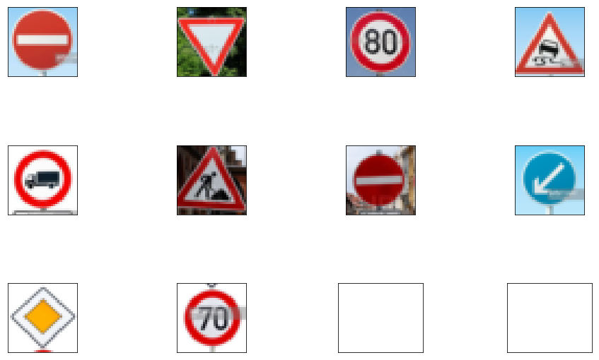

```python
### Load the images and plot them here.
### Feel free to use as many code cells as needed.

import os
from scipy import misc

def _loadAndShowExtraImages():
    # The raw images are in the extra directory. Data.csv specifies label, file name, and the
    # image 'patch' to extract and resize.
    root = 'extra'
    rows = np.genfromtxt(
        fname=os.path.join(root, 'Data.csv'), delimiter=',',
        usecols=tuple(range(5)),
        dtype=[('label', np.int32), ('fileName', np.object), ('cy', np.float64), ('cx', np.float64), ('frac', np.float64)],
        skip_header=0, skip_footer=0)
    #print(rows.shape, rows.dtype)
    #print(rows)

    numPerRow = 4
    numRows = (rows.shape[0] + numPerRow - 1) // numPerRow
    fig, axes = plt.subplots(
        numRows, numPerRow, figsize=(15, 3 * numRows),
        subplot_kw={'xticks': [], 'yticks': []})
    fig.subplots_adjust(hspace=1.0, wspace=1.0)

    labels = rows['label']
    pixels = np.zeros((rows.shape[0], 32, 32, 3), np.uint8)
    for i, rec in enumerate(rows):
        filePath = os.path.join(root, rec['fileName'].decode('utf-8'))
        image = misc.imread(filePath, mode='RGB')
        #print(type(image), image.shape)
        assert len(image.shape) == 3 and image.shape[2] == 3

        # To extract the pixels, use the center (specified as fractions of image dimensions) and
        # the 'fraction' of the narrower dimension that the patch occupies.
        y = int(rec['cy'] * image.shape[0])
        x = int(rec['cx'] * image.shape[1])
        dz = int(rec['frac'] * min(image.shape[0], image.shape[1]))
        yMin = max(0, y - dz // 2)
        xMin = max(0, x - dz // 2)
        yLim = min(image.shape[0], yMin + dz)
        xLim = min(image.shape[1], xMin + dz)
        pixels[i] = misc.imresize(image[yMin : yLim, xMin : xLim], size=(32, 32))

        axes.flat[i].imshow(pixels[i])

    # Return the labels and pixels.
    return labels, pixels

_labelsExtra, _imagesExtra = _loadAndShowExtraImages()
```

### Predict the Sign Type for Each Image

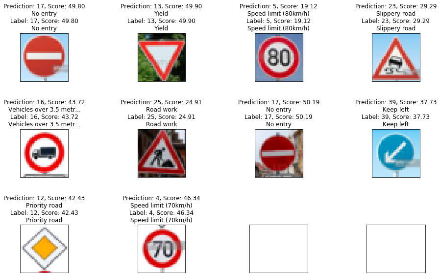

```python
### Run the predictions here and use the model to output the prediction for each image.
### Make sure to pre-process the images with the same pre-processing pipeline used earlier.
### Feel free to use as many code cells as needed.

def _predictAndShowResults(labels, pixels):
    # Normalize the pixels.
    features = _normImages(pixels)

    # Run the images through the classifier to get logits.
    logits = _sess.run(
        g_logits,
        feed_dict={
            g_x: features,
            g_kr1: 1.0, g_kr2: 1.0, g_kr3: 1.0
        })

    # Get the predicted classes.
    predictions = np.argmax(logits, axis=-1)

    numPerRow = 4
    numRows = (labels.shape[0] + numPerRow - 1) // numPerRow
    fig, axes = plt.subplots(
        numRows, numPerRow, figsize=(15, 3 * numRows),
        subplot_kw={'xticks': [], 'yticks': []})
    fig.subplots_adjust(hspace=1.0, wspace=1.0)

    lenMax = 25
    def _trim(txt):
        if len(txt) <= lenMax:
            return txt
        return txt[:lenMax - 3] + '...'

    # Show the images again with the label, prediction, and raw scores (not probabilities).
    for i, ax in enumerate(axes.flat):
        if i >= pixels.shape[0]:
            break
        ax.imshow(pixels[i])

        label = labels[i]
        txtLab = _trim(signNames[label])
        pred = predictions[i]
        txtPred = _trim(signNames[pred])
        ax.set_title(
            "Prediction: {}, Score: {:3.2f}\n{}\nLabel: {}, Score: {:3.2f}\n{}".format(
                pred, logits[i, pred], txtPred,
                label, logits[i, label], txtLab
            )
        )

    plt.show()
    return logits

_logitsExtra = _predictAndShowResults(_labelsExtra, _imagesExtra)
```

### Analyze Performance

```python
### Calculate the accuracy for these 5 new images.
### For example, if the model predicted 1 out of 5 signs correctly, it's 20% accurate on these new images.

def _showAccuracy(labels, logits):
    num = labels.shape[0]
    assert num == logits.shape[0]
    predictions = np.argmax(logits, axis=-1)

    correct = sum(np.equal(labels, predictions).astype(np.int32))
    print("Predicted {} of {} correctly for {:.02f}%".format(correct, num, 100.0 * correct / num))

_showAccuracy(_labelsExtra, _logitsExtra)
```

```
Predicted 10 of 10 correctly for 100.00%
```

### Output Top 5 Softmax Probabilities For Each Image Found on the Web

For each of the new images, print out the model's softmax probabilities to show the **certainty** of the model's predictions (limit the output to the top 5 probabilities for each image). [`tf.nn.top_k`](https://www.tensorflow.org/versions/r0.12/api_docs/python/nn.html#top_k) could prove helpful here.

The example below demonstrates how tf.nn.top_k can be used to find the top k predictions for each image.

`tf.nn.top_k` will return the values and indices (class ids) of the top k predictions. So if k=3, for each sign, it'll return the 3 largest probabilities (out of a possible 43) and the correspoding class ids.

Take this numpy array as an example. The values in the array represent predictions. The array contains softmax probabilities for five candidate images with six possible classes. `tf.nn.top_k` is used to choose the three classes with the highest probability:

```
# (5, 6) array
a = np.array([[ 0.24879643,  0.07032244,  0.12641572,  0.34763842,  0.07893497,
         0.12789202],
       [ 0.28086119,  0.27569815,  0.08594638,  0.0178669 ,  0.18063401,
         0.15899337],
       [ 0.26076848,  0.23664738,  0.08020603,  0.07001922,  0.1134371 ,
         0.23892179],
       [ 0.11943333,  0.29198961,  0.02605103,  0.26234032,  0.1351348 ,
         0.16505091],
       [ 0.09561176,  0.34396535,  0.0643941 ,  0.16240774,  0.24206137,
         0.09155967]])
```

Running it through `sess.run(tf.nn.top_k(tf.constant(a), k=3))` produces:

```
TopKV2(values=array([[ 0.34763842,  0.24879643,  0.12789202],
       [ 0.28086119,  0.27569815,  0.18063401],
       [ 0.26076848,  0.23892179,  0.23664738],
       [ 0.29198961,  0.26234032,  0.16505091],
       [ 0.34396535,  0.24206137,  0.16240774]]), indices=array([[3, 0, 5],
       [0, 1, 4],
       [0, 5, 1],
       [1, 3, 5],
       [1, 4, 3]], dtype=int32))
```

Looking just at the first row we get `[ 0.34763842, 0.24879643, 0.12789202]`, you can confirm these are the 3 largest probabilities in `a`. You'll also notice `[3, 0, 5]` are the corresponding indices.

```python
### Print out the top five softmax probabilities for the predictions on the German traffic sign images found on the web.
### Feel free to use as many code cells as needed.

def _showTopNSoftMax(labels, logits, n):
    num = logits.shape[0]

    g_logs = tf.constant(logits)
    g_sm = tf.nn.softmax(g_logs)
    g_top = tf.nn.top_k(g_sm, k=n)

    vals, inds = _sess.run(g_top)
    assert len(vals.shape) == 2 and vals.shape[0] == num and vals.shape[1] == n
    assert vals.shape == inds.shape

    for i in range(num):
        print("Top {} predictions for image {} with label {} '{}'".format(n, i, labels[i], signNames[labels[i]]))
        for j in range(n):
            c = inds[i, j]
            print(
                "  Class: {}, Score: {:03f}, Probability: {:.03f}, Name: {}".format(
                    c, logits[i, c], vals[i, j], signNames[c]
                )
            )

_showTopNSoftMax(_labelsExtra, _logitsExtra, 5)
```

```
Top 5 predictions for image 0 with label 17 'No entry'
  Class: 17, Score: 49.800625, Probability: 1.000, Name: No entry
  Class: 14, Score: 15.706025, Probability: 0.000, Name: Stop
  Class: 9, Score: 8.059810, Probability: 0.000, Name: No passing
  Class: 0, Score: 2.655849, Probability: 0.000, Name: Speed limit (20km/h)
  Class: 22, Score: 0.023133, Probability: 0.000, Name: Bumpy road
Top 5 predictions for image 1 with label 13 'Yield'
  Class: 13, Score: 49.903358, Probability: 1.000, Name: Yield
  Class: 9, Score: 15.174875, Probability: 0.000, Name: No passing
  Class: 15, Score: 9.246969, Probability: 0.000, Name: No vehicles
  Class: 2, Score: 2.902282, Probability: 0.000, Name: Speed limit (50km/h)
  Class: 3, Score: 1.561353, Probability: 0.000, Name: Speed limit (60km/h)
Top 5 predictions for image 2 with label 5 'Speed limit (80km/h)'
  Class: 5, Score: 19.120239, Probability: 0.999, Name: Speed limit (80km/h)
  Class: 1, Score: 11.713122, Probability: 0.001, Name: Speed limit (30km/h)
  Class: 2, Score: 11.127168, Probability: 0.000, Name: Speed limit (50km/h)
  Class: 0, Score: 7.895446, Probability: 0.000, Name: Speed limit (20km/h)
  Class: 3, Score: 5.960794, Probability: 0.000, Name: Speed limit (60km/h)
Top 5 predictions for image 3 with label 23 'Slippery road'
  Class: 23, Score: 29.286413, Probability: 0.961, Name: Slippery road
  Class: 30, Score: 26.079258, Probability: 0.039, Name: Beware of ice/snow
  Class: 19, Score: 9.483726, Probability: 0.000, Name: Dangerous curve to the left
  Class: 29, Score: 5.147949, Probability: 0.000, Name: Bicycles crossing
  Class: 20, Score: 1.895086, Probability: 0.000, Name: Dangerous curve to the right
Top 5 predictions for image 4 with label 16 'Vehicles over 3.5 metric tons prohibited'
  Class: 16, Score: 43.719360, Probability: 1.000, Name: Vehicles over 3.5 metric tons prohibited
  Class: 9, Score: 23.284674, Probability: 0.000, Name: No passing
  Class: 15, Score: 13.669271, Probability: 0.000, Name: No vehicles
  Class: 41, Score: 0.736199, Probability: 0.000, Name: End of no passing
  Class: 32, Score: -4.657762, Probability: 0.000, Name: End of all speed and passing limits
Top 5 predictions for image 5 with label 25 'Road work'
  Class: 25, Score: 24.912117, Probability: 1.000, Name: Road work
  Class: 27, Score: 7.354095, Probability: 0.000, Name: Pedestrians
  Class: 33, Score: 1.101917, Probability: 0.000, Name: Turn right ahead
  Class: 24, Score: 0.413363, Probability: 0.000, Name: Road narrows on the right
  Class: 26, Score: -0.121683, Probability: 0.000, Name: Traffic signals
Top 5 predictions for image 6 with label 17 'No entry'
  Class: 17, Score: 50.194107, Probability: 1.000, Name: No entry
  Class: 14, Score: 12.471080, Probability: 0.000, Name: Stop
  Class: 9, Score: 4.205602, Probability: 0.000, Name: No passing
  Class: 23, Score: 1.086516, Probability: 0.000, Name: Slippery road
  Class: 0, Score: 0.864839, Probability: 0.000, Name: Speed limit (20km/h)
Top 5 predictions for image 7 with label 39 'Keep left'
  Class: 39, Score: 37.725521, Probability: 1.000, Name: Keep left
  Class: 40, Score: 20.082232, Probability: 0.000, Name: Roundabout mandatory
  Class: 33, Score: 18.359850, Probability: 0.000, Name: Turn right ahead
  Class: 37, Score: 17.656765, Probability: 0.000, Name: Go straight or left
  Class: 34, Score: 11.702733, Probability: 0.000, Name: Turn left ahead
Top 5 predictions for image 8 with label 12 'Priority road'
  Class: 12, Score: 42.434284, Probability: 1.000, Name: Priority road
  Class: 14, Score: 8.945109, Probability: 0.000, Name: Stop
  Class: 17, Score: 5.993159, Probability: 0.000, Name: No entry
  Class: 42, Score: 5.074652, Probability: 0.000, Name: End of no passing by vehicles over 3.5 metric tons
  Class: 10, Score: 1.819171, Probability: 0.000, Name: No passing for vehicles over 3.5 metric tons
Top 5 predictions for image 9 with label 4 'Speed limit (70km/h)'
  Class: 4, Score: 46.335018, Probability: 1.000, Name: Speed limit (70km/h)
  Class: 0, Score: 24.749758, Probability: 0.000, Name: Speed limit (20km/h)
  Class: 1, Score: 9.680217, Probability: 0.000, Name: Speed limit (30km/h)
  Class: 18, Score: -1.497452, Probability: 0.000, Name: General caution
  Class: 26, Score: -3.363060, Probability: 0.000, Name: Traffic signals
```

### Project Writeup

Once you have completed the code implementation, document your results in a project writeup using this [template](https://github.com/udacity/CarND-Traffic-Sign-Classifier-Project/blob/master/writeup_template.md) as a guide. The writeup can be in a markdown or pdf file.

## Step 4 (Optional): Visualize the Neural Network's State with Test Images

This Section is not required to complete but acts as an additional excersise for understaning the output of a neural network's weights. While neural networks can be a great learning device they are often referred to as a black box. We can understand what the weights of a neural network look like better by plotting their feature maps. After successfully training your neural network you can see what it's feature maps look like by plotting the output of the network's weight layers in response to a test stimuli image. From these plotted feature maps, it's possible to see what characteristics of an image the network finds interesting. For a sign, maybe the inner network feature maps react with high activation to the sign's boundary outline or to the contrast in the sign's painted symbol.

Provided for you below is the function code that allows you to get the visualization output of any tensorflow weight layer you want. The inputs to the function should be a stimuli image, one used during training or a new one you provided, and then the tensorflow variable name that represents the layer's state during the training process, for instance if you wanted to see what the LeNet lab's feature maps looked like for it's second convolutional layer you could enter conv2 as the tf_activation variable.

For an example of what feature map outputs look like, check out NVIDIA's results in their paper [End-to-End Deep Learning for Self-Driving Cars](https://devblogs.nvidia.com/parallelforall/deep-learning-self-driving-cars/) in the section Visualization of internal CNN State. NVIDIA was able to show that their network's inner weights had high activations to road boundary lines by comparing feature maps from an image with a clear path to one without. Try experimenting with a similar test to show that your trained network's weights are looking for interesting features, whether it's looking at differences in feature maps from images with or without a sign, or even what feature maps look like in a trained network vs a completely untrained one on the same sign image.

[figure not shown]

Your output should look something like this (above)

[figure not shown]

```python
### Visualize your network's feature maps here.
### Feel free to use as many code cells as needed.

# image_input: the test image being fed into the network to produce the feature maps
# tf_activation: should be a tf variable name used during your training procedure that represents the calculated state of a specific weight layer
# activation_min/max: can be used to view the activation contrast in more detail, by default matplot sets min and max to the actual min and max values of the output
# plt_num: used to plot out multiple different weight feature map sets on the same block, just extend the plt number for each new feature map entry

def outputFeatureMap(sess, image_input, tf_activation, activation_min=-1, activation_max=-1 ,plt_num=1):
    # Here make sure to preprocess your image_input in a way your network expects
    # with size, normalization, ect if needed
    # image_input =
    # Note: x should be the same name as your network's tensorflow data placeholder variable
    # If you get an error tf_activation is not defined it may be having trouble accessing the variable from inside a function
    activation = tf_activation.eval(session=sess, feed_dict={g_x: image_input, g_kr1: 1.0, g_kr2: 1.0, g_kr3: 1.0})
    featuremaps = activation.shape[3]
    plt.figure(plt_num, figsize=(15,15))
    for featuremap in range(featuremaps):
        plt.subplot(6, 8, featuremap+1) # sets the number of feature maps to show on each row and column
        plt.title('FeatureMap ' + str(featuremap)) # displays the feature map number
        if activation_min != -1 & activation_max != -1:
            plt.imshow(activation[0,:,:, featuremap], interpolation="nearest", vmin =activation_min, vmax=activation_max, cmap="gray")
        elif activation_max != -1:
            plt.imshow(activation[0,:,:, featuremap], interpolation="nearest", vmax=activation_max, cmap="gray")
        elif activation_min !=-1:
            plt.imshow(activation[0,:,:, featuremap], interpolation="nearest", vmin=activation_min, cmap="gray")
        else:
            plt.imshow(activation[0,:,:, featuremap], interpolation="nearest", cmap="gray")

which = 2
outputFeatureMap(_sess, _imagesExtra[which:which+1], _layersAll[0])
```

[figure not shown]

```python
outputFeatureMap(_sess, _imagesExtra[which:which+1], _layersAll[1])
```

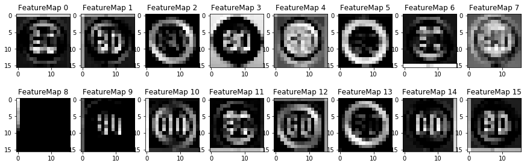

```python
outputFeatureMap(_sess, _imagesExtra[which:which+1], _layersAll[2])
```

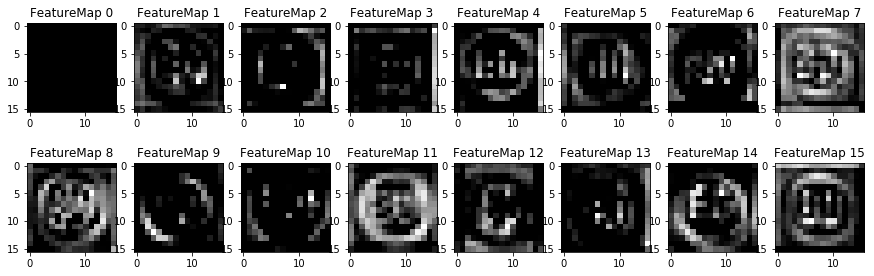

```python
outputFeatureMap(_sess, _imagesExtra[which:which+1], _layersAll[3])
```

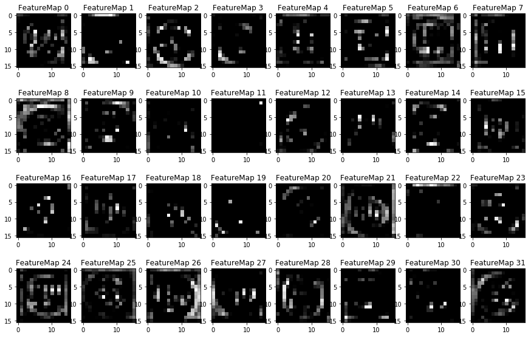

```python
outputFeatureMap(_sess, _imagesExtra[which:which+1], _layersAll[4])
```